# Structural validity assessment

Does the AMP function comparably in high and low influence-aware participants?

Ian Hussey & Jamie Cummins

21 May, 2019

These analyses assess measurement invariance of the traditional AMP between individuals who are high vs. low influence aware, as assessed via a median split of IA rates on the IA-AMP. As the AMP was completed prior to the IA-AMP, any such invariance is attributable only to the traditional AMP itself.

These analyses employ a parcelling method, whereby trials that were preceeded by one prime type vs. the other (e.g., positive vs negative) were scored separately. In addition, three separate parcels were created for the first, second, and third half of the test by order of presentation, per prime type. This provided 3 parcels per latent variable (ratings of stimuli by prime type).

Critically, studies to date using the AMP have typically (if sometimes implicitly) assumed that these two latent variables are negatively correlated: extreme AMP scores represent differential evaluations of stimuli following one prime type relative to the other. As such, for the measure to be structurally valid, it is assumed that these two latent variables be negatively correlated.

The following analyses test this assumption, followed by tests of measurement invariance between high and low influence-awareness groups.

For data to be included in these analyses, the experiment had to include both an AMP and IA-AMP. Analyses were then grouped by domain congruence between the AMP and IA-AMP.

```r
# dependencies
library(tidyverse)
library(lavaan)
library(semTools)
library(semPlot)
library(timesavers)
library(knitr)
library(kableExtra)
```

# Positive-Negative AMPs and IA-AMPs

Experiments 2 and 5 contain positive-negative (Mann) AMPs and IA-AMP. Rosseel argues that when the latent construct’s status concerns within subject effects, as is the case here, that it is appropriate to pool data rather than construct a multilevel SEM model.

See:

- https://users.ugent.be/~yrosseel/lavaan/zurich2017/MULTILEVEL/lavaan_multilevel_zurich2017.pdf
- Stapleton, L.M., Yang, J.S., & Hancock, G.R. (2016). Construct meaning in multilevel settings. Journal of Educational and Behavioral Statistics, 41, 481–520.

## Data

```r
# get data
temp_1 <- read.csv("../experiment 2/data/processed/processed_data.csv") %>%
  dplyr::select(subject, influence_rate, self_exclusion_1, complete_data)

temp_2 <- read.csv("../experiment 5/data/processed/processed_data.csv") %>%
  dplyr::select(subject, influence_rate, self_exclusion_1, complete_data)

task_level_data <- bind_rows(temp_1, temp_2)


temp_1 <- read.csv("../experiment 2/data/processed/trial_level_amp_positive_negative_data.csv")

temp_2 <- read.csv("../experiment 5/data/processed/trial_level_amp_positive_negative_data.csv")

trial_level_amp_data <- bind_rows(temp_1, temp_2)

# exclusions
task_level_data_exclusions <- task_level_data %>%
  filter(self_exclusion_1 == "Yes, use my data" & complete_data == TRUE)

trial_level_amp_data_exclusions <- trial_level_amp_data %>%
  filter(self_exclusion_1 == "Yes, use my data" & complete_data == TRUE)
```

```r
# influence rate from the IA AMP
data_influence_rate_groups <- task_level_data_exclusions %>%
  dplyr::mutate(influence_rate_group = as.factor(ifelse(influence_rate >= median(influence_rate), "high", "low"))) %>%
  dplyr::mutate(influence_rate_group = forcats::fct_relevel(influence_rate_group, "low", "high")) %>%
  select(subject, influence_rate_group)

# AMP effect from AMP - politics, democrats only
data_reshaped <- trial_level_amp_data_exclusions %>%
  # arrange the trials by prime type and order of completion
  arrange(subject, prime_type) %>%
  group_by(subject) %>%
  dplyr::mutate(AMP_trial = row_number()) %>%
  ungroup() %>%
  rownames_to_column() %>%
  select(subject, AMP_trial, rating) %>%
  dplyr::mutate(parcel = ifelse(AMP_trial <= 10, "parcel_1",
                                ifelse(AMP_trial <= 20, "parcel_2",
                                       ifelse(AMP_trial <= 30, "parcel_3",
                                              ifelse(AMP_trial <= 40, "parcel_4",
                                                     ifelse(AMP_trial <= 50, "parcel_5",
                                                            ifelse(AMP_trial <= 60, "parcel_6", NA))))))) %>%
  group_by(subject, parcel) %>%
  dplyr::summarize(rating_sum = sum(rating)) %>%
  ungroup() %>%
  spread(parcel, rating_sum) %>%
  left_join(data_influence_rate_groups, by = "subject")

#levels(data_reshaped$influence_rate_group)
```

## Fit CFA

```r
model <- "AMP_primetype_A =~ parcel_1 + parcel_2 + parcel_3
          AMP_primetype_B =~ parcel_4 + parcel_5 + parcel_6"

# fit the configural model
fit_configural <- data_reshaped %>%
  cfa(model = model,
      data  = .,
      estimator = "ML",
      group = "influence_rate_group")

# constrain slopes
fit_metric <- data_reshaped %>%
  cfa(model = model,
      data  = .,
      estimator = "ML",
      group = "influence_rate_group",
      group.equal = "loadings")

# constrain intercepts
fit_scalar <- data_reshaped %>%
  cfa(model = model,
      data  = .,
      estimator = "ML",
      group = "influence_rate_group",
      group.equal = c( "loadings", "intercepts"))

# summarize these cfa fit indices, and their change across nested models
results <- compareFit(fit_configural, fit_metric, fit_scalar, nested = TRUE) %>%
  summary()

fit_indices <- results$fit.indices %>%
  rownames_to_column(var = "test") %>%
  round_df(3)

fit_deltas <- results$fit.diff %>%
  rownames_to_column(var = "test") %>%
  dplyr::mutate(MI = ifelse(rmsea > 0.01 | cfi < -0.015, "failed", "passed")) %>%
  round_df(3)
```

```r
fit_indices %>%
  select(-aic, -bic) %>%
  kable() %>%
  kable_styling(bootstrap_options = c("striped", "hover", "condensed"), full_width = FALSE)
```

| test | chisq | df | pvalue | cfi | tli | rmsea | srmr |
| --- | --- | --- | --- | --- | --- | --- | --- |
| fit_configural | 79.157 | 16 | 0 | 0.966 | 0.936 | 0.125 | 0.063 |
| fit_metric | 87.827 | 20 | 0 | 0.964 | 0.945 | 0.116 | 0.075 |
| fit_scalar | 94.207 | 24 | 0 | 0.962 | 0.953 | 0.108 | 0.078 |

```r
fit_deltas %>%
  select(-aic, -bic) %>%
  kable() %>%
  kable_styling(bootstrap_options = c("striped", "hover", "condensed"), full_width = FALSE)
```

| test | df | cfi | tli | rmsea | srmr | MI |
| --- | --- | --- | --- | --- | --- | --- |
| fit_metric - fit_configural | 4 | -0.003 | 0.009 | -0.009 | 0.012 | passed |
| fit_scalar - fit_scalar | 4 | -0.001 | 0.008 | -0.008 | 0.002 | passed |

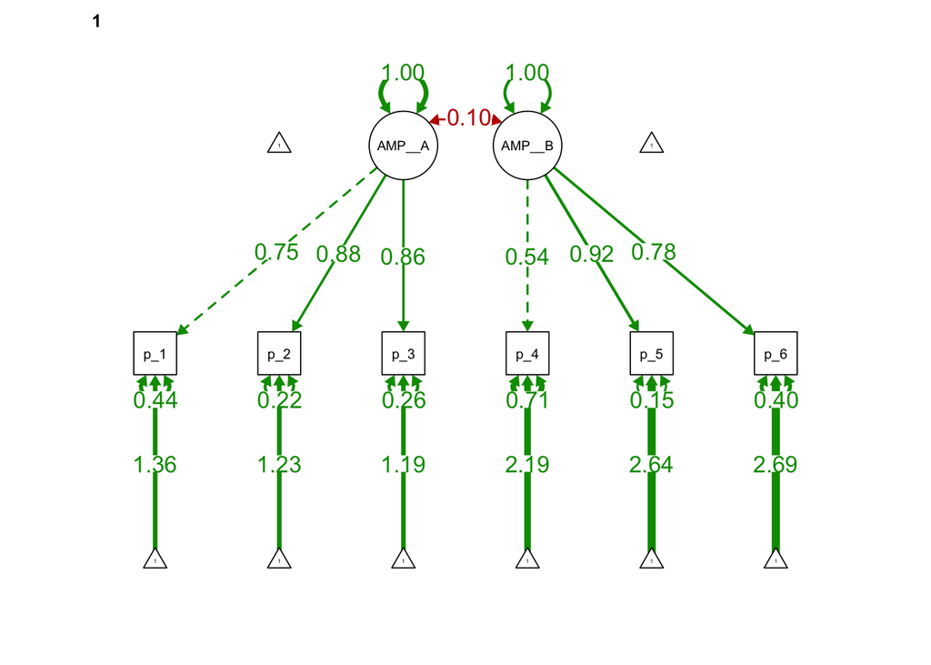

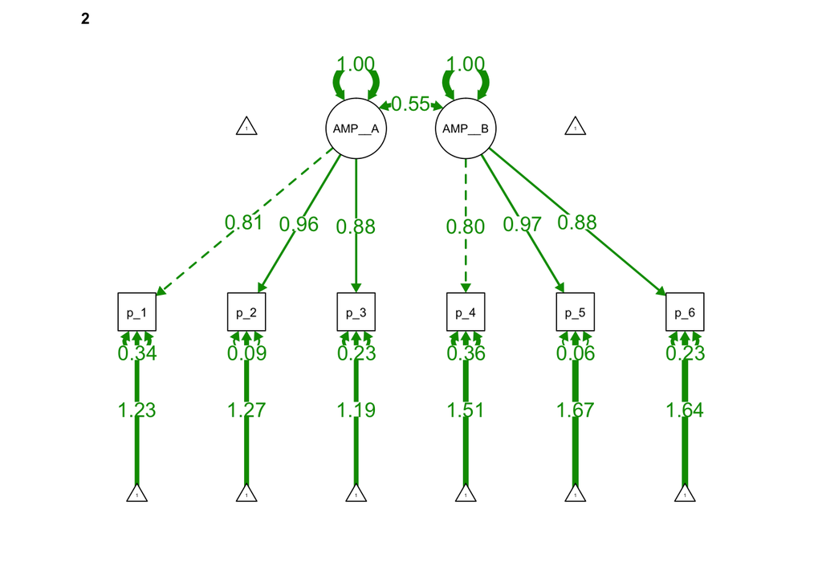

```r
# plot configural model
semPaths(fit_configural,
         "est",
         "std",
         fade = FALSE,
         ask = FALSE,
         curveAdjacent = TRUE,
         edge.label.cex = 1.2)
```

```r
# table
summary(fit_configural, standardized = TRUE)
```

```
## lavaan 0.6-3 ended normally after 79 iterations
##
##   Optimization method                           NLMINB
##   Number of free parameters                         38
##
##   Number of observations per group
##   high                                             261
##   low                                              245
##
##   Estimator                                         ML
##   Model Fit Test Statistic                      79.157
##   Degrees of freedom                                16
##   P-value (Chi-square)                           0.000
##
## Chi-square for each group:
##
##   high                                          35.967
##   low                                           43.191
##
## Parameter Estimates:
##
##   Information                                 Expected
##   Information saturated (h1) model          Structured
##   Standard Errors                             Standard
##
##
## Group 1 [high]:
##
## Latent Variables:
##                      Estimate  Std.Err  z-value  P(>|z|)   Std.lv  Std.all
##   AMP_primetype_A =~
##     parcel_1            1.000                               1.900    0.749
##     parcel_2            1.313    0.098   13.466    0.000    2.495    0.884
##     parcel_3            1.276    0.095   13.385    0.000    2.424    0.859
##   AMP_primetype_B =~
##     parcel_4            1.000                               1.345    0.535
##     parcel_5            1.800    0.233    7.726    0.000    2.421    0.924
##     parcel_6            1.502    0.178    8.414    0.000    2.020    0.778
##
## Covariances:
```

[output cut: 51 more lines]

```
##    .parcel_5          5.473    0.209   26.143    0.000    5.473    1.670
##    .parcel_6          5.445    0.212   25.709    0.000    5.445    1.642
##     AMP_primetyp_A    0.000                               0.000    0.000
##     AMP_primetyp_B    0.000                               0.000    0.000
##
## Variances:
##                    Estimate  Std.Err  z-value  P(>|z|)   Std.lv  Std.all
##    .parcel_1          2.986    0.319    9.362    0.000    2.986    0.337
##    .parcel_2          0.854    0.259    3.303    0.001    0.854    0.087
##    .parcel_3          2.361    0.308    7.661    0.000    2.361    0.229
##    .parcel_4          3.610    0.373    9.683    0.000    3.610    0.363
##    .parcel_5          0.652    0.280    2.327    0.020    0.652    0.061
##    .parcel_6          2.550    0.327    7.794    0.000    2.550    0.232
##     AMP_primetyp_A    5.864    0.772    7.599    0.000    1.000    1.000
##     AMP_primetyp_B    6.336    0.857    7.396    0.000    1.000    1.000
```

# Politics AMP and positive-negative IA-AMP

## Data

```r
# get data
task_level_data <- read.csv("../experiment 3/data/processed/processed_data.csv")

trial_level_amp_data <- read.csv("../experiment 3/data/processed/trial_level_amp_obama_trump_data.csv")

# exclusions
task_level_data_exclusions <- task_level_data %>%
  filter(self_exclusion_1 == "Yes, use my data" & complete_data == TRUE &
           party %in% c("democrat"))

trial_level_amp_data_exclusions <- trial_level_amp_data %>%
  filter(self_exclusion_1 == "Yes, use my data" & complete_data == TRUE &
           party %in% c("democrat"))
```

```r
# influence rate from the IA AMP
data_influence_rate_groups <- task_level_data_exclusions %>%
  dplyr::mutate(influence_rate_group = as.factor(ifelse(influence_rate >= median(influence_rate), "high", "low"))) %>%
  dplyr::mutate(influence_rate_group = forcats::fct_relevel(influence_rate_group, "low", "high")) %>%
  select(subject, influence_rate_group)

# AMP effect from AMP - politics, democrats only
data_reshaped <- trial_level_amp_data_exclusions %>%
  # arrange the trials by prime type and order of completion
  arrange(subject, prime_type) %>%
  group_by(subject) %>%
  dplyr::mutate(AMP_trial = row_number()) %>%
  ungroup() %>%
  rownames_to_column() %>%
  select(subject, AMP_trial, rating) %>%
  dplyr::mutate(parcel = ifelse(AMP_trial <= 12, "parcel_1",
                                ifelse(AMP_trial <= 24, "parcel_2",
                                       ifelse(AMP_trial <= 36, "parcel_3",
                                              ifelse(AMP_trial <= 48, "parcel_4",
                                                     ifelse(AMP_trial <= 60, "parcel_5",
                                                            ifelse(AMP_trial <= 72, "parcel_6", NA))))))) %>%
  group_by(subject, parcel) %>%
  dplyr::summarize(rating_sum = sum(rating)) %>%
  ungroup() %>%
  spread(parcel, rating_sum) %>%
  left_join(data_influence_rate_groups, by = "subject")

#levels(data_reshaped$influence_rate_group)
```

## Fit CFA

```r
model <- "AMP_primetype_A =~ parcel_1 + parcel_2 + parcel_3
          AMP_primetype_B =~ parcel_4 + parcel_5 + parcel_6"

# fit the configural model
fit_configural <- data_reshaped %>%
  cfa(model = model,
      data  = .,
      estimator = "ML",
      group = "influence_rate_group")

# constrain slopes
fit_metric <- data_reshaped %>%
  cfa(model = model,
      data  = .,
      estimator = "ML",
      group = "influence_rate_group",
      group.equal = "loadings")

# constrain intercepts
fit_scalar <- data_reshaped %>%
  cfa(model = model,
      data  = .,
      estimator = "ML",
      group = "influence_rate_group",
      group.equal = c( "loadings", "intercepts"))

# summarize these cfa fit indices, and their change across nested models
results <- compareFit(fit_configural, fit_metric, fit_scalar, nested = TRUE) %>%
  summary()

fit_indices <- results$fit.indices %>%
  rownames_to_column(var = "test") %>%
  round_df(3)

fit_deltas <- results$fit.diff %>%
  rownames_to_column(var = "test") %>%
  dplyr::mutate(MI = ifelse(rmsea > 0.01 | cfi < -0.015, "failed", "passed")) %>%
  round_df(3)
```

```r
fit_indices %>%
  select(-aic, -bic) %>%
  kable() %>%
  kable_styling(bootstrap_options = c("striped", "hover", "condensed"), full_width = FALSE)
```

| test | chisq | df | pvalue | cfi | tli | rmsea | srmr |
| --- | --- | --- | --- | --- | --- | --- | --- |
| fit_configural | 24.256 | 16 | 0.084 | 0.989 | 0.979 | 0.082 | 0.041 |
| fit_metric | 32.285 | 20 | 0.040 | 0.983 | 0.975 | 0.089 | 0.057 |
| fit_scalar | 44.654 | 24 | 0.006 | 0.972 | 0.965 | 0.105 | 0.060 |

```r
fit_deltas %>%
  select(-aic, -bic) %>%
  kable() %>%
  kable_styling(bootstrap_options = c("striped", "hover", "condensed"), full_width = FALSE)
```

| test | df | cfi | tli | rmsea | srmr | MI |
| --- | --- | --- | --- | --- | --- | --- |
| fit_metric - fit_configural | 4 | -0.005 | -0.004 | 0.007 | 0.016 | passed |
| fit_scalar - fit_scalar | 4 | -0.011 | -0.010 | 0.016 | 0.003 | failed |

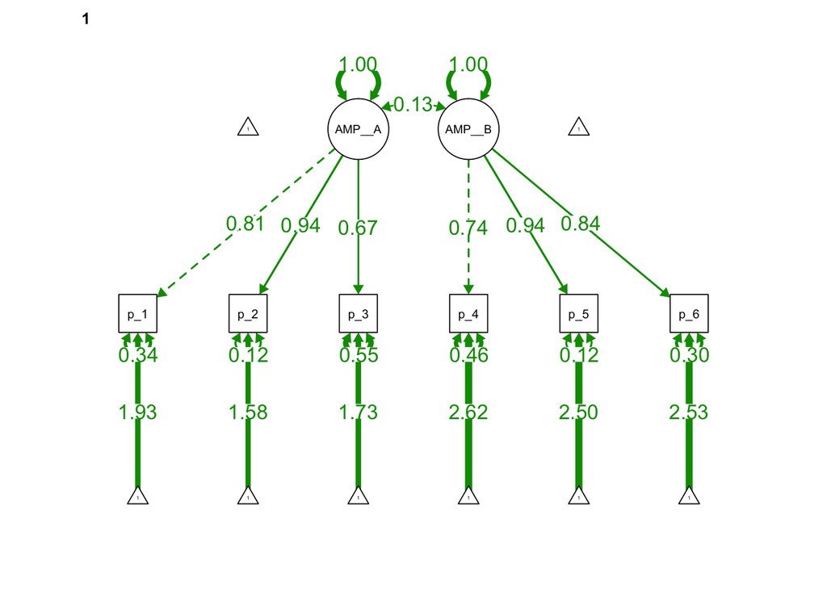

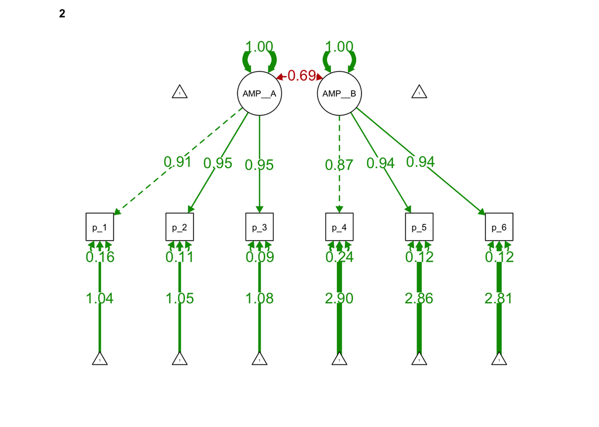

```r
# plot configural model
semPaths(fit_configural,
         "est",
         "std",
         fade = FALSE,
         ask = FALSE,
         curveAdjacent = TRUE,
         edge.label.cex = 1.2)
```

```r
# table
summary(fit_configural, standardized = TRUE)
```

```
## lavaan 0.6-3 ended normally after 82 iterations
##
##   Optimization method                           NLMINB
##   Number of free parameters                         38
##
##   Number of observations per group
##   low                                               77
##   high                                              78
##
##   Estimator                                         ML
##   Model Fit Test Statistic                      24.256
##   Degrees of freedom                                16
##   P-value (Chi-square)                           0.084
##
## Chi-square for each group:
##
##   low                                           11.164
##   high                                          13.091
##
## Parameter Estimates:
##
##   Information                                 Expected
##   Information saturated (h1) model          Structured
##   Standard Errors                             Standard
##
##
## Group 1 [low]:
##
## Latent Variables:
##                      Estimate  Std.Err  z-value  P(>|z|)   Std.lv  Std.all
##   AMP_primetype_A =~
##     parcel_1            1.000                               2.333    0.815
##     parcel_2            1.312    0.178    7.384    0.000    3.060    0.938
##     parcel_3            0.909    0.145    6.261    0.000    2.120    0.671
##   AMP_primetype_B =~
##     parcel_4            1.000                               2.166    0.736
##     parcel_5            1.310    0.176    7.436    0.000    2.838    0.939
##     parcel_6            1.130    0.155    7.309    0.000    2.447    0.838
##
## Covariances:
```

[output cut: 51 more lines]

```
##    .parcel_5          8.679    0.344   25.248    0.000    8.679    2.859
##    .parcel_6          8.962    0.361   24.824    0.000    8.962    2.811
##     AMP_primetyp_A    0.000                               0.000    0.000
##     AMP_primetyp_B    0.000                               0.000    0.000
##
## Variances:
##                    Estimate  Std.Err  z-value  P(>|z|)   Std.lv  Std.all
##    .parcel_1          1.825    0.378    4.831    0.000    1.825    0.164
##    .parcel_2          1.468    0.390    3.763    0.000    1.468    0.106
##    .parcel_3          1.233    0.361    3.417    0.001    1.233    0.093
##    .parcel_4          2.342    0.456    5.132    0.000    2.342    0.241
##    .parcel_5          1.103    0.322    3.431    0.001    1.103    0.120
##    .parcel_6          1.208    0.354    3.412    0.001    1.208    0.119
##     AMP_primetyp_A    9.270    1.769    5.241    0.000    1.000    1.000
##     AMP_primetyp_B    7.387    1.534    4.814    0.000    1.000    1.000
```